# Random Forest Modelling of the Lake Erie microbial community

### plots

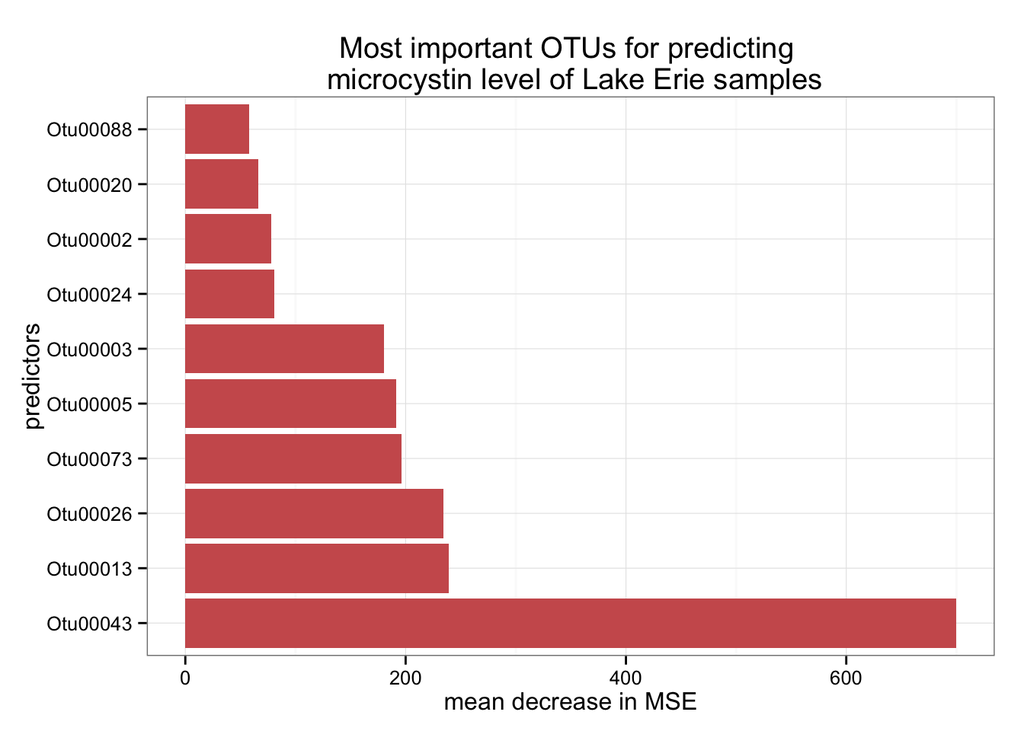

```r
# Select the importance vactor for the predictors.
# For a regression tree this is measured by mean decrease in MSE
# due to that variable
imp <- importance(rf.mc)
imp <- data.frame(predictors=rownames(imp),imp)

# Order the predictor levels by importance
imp.sort <- arrange(imp,desc(IncNodePurity))
imp.sort$predictors <- factor(imp.sort$predictors,levels=imp.sort$predictors)

# Select the top 10 predictors
imp.10 <- imp.sort[1:10,]

# ggplot
ggplot(imp.10,aes(x=predictors,y=IncNodePurity))+
  geom_bar(stat="identity",fill="indianred") +
  coord_flip()+
  ggtitle("Most important OTUs for predicting \n microcystin level of Lake Erie samples") +
  ylab("mean decrease in MSE")
```

```r
# What are those OTUs?
otunames<- imp.10$predictors
r <- rownames(tax_table(FCNA)) %in% otunames
kable(tax_table(FCNA)[r,])
```

|  | Kingdom | Phylum | Class | Order | Family | Genus |
| --- | --- | --- | --- | --- | --- | --- |
| Otu00002 | Bacteria | Actinobacteria | Actinobacteria | Frankiales | Sporichthyaceae | hgcI_clade |
| Otu00003 | Bacteria | Actinobacteria | Actinobacteria | Frankiales | Sporichthyaceae | hgcI_clade |
| Otu00005 | Bacteria | Cyanobacteria | Cyanobacteria | SubsectionI | FamilyI | Microcystis |
| Otu00013 | Bacteria | Proteobacteria | Alphaproteobacteria | Rhodospirillales | Acetobacteraceae | Roseomonas |
| Otu00020 | Bacteria | Bacteroidetes | Cytophagia | Cytophagales | Cytophagaceae | unclassified |
| Otu00024 | Bacteria | Cyanobacteria | Cyanobacteria | SubsectionI | FamilyI | unclassified |
| Otu00026 | Bacteria | Verrucomicrobia | OPB35_soil_group | unclassified | unclassified | unclassified |
| Otu00043 | Bacteria | Cyanobacteria | Cyanobacteria | SubsectionIII | FamilyI | Pseudanabaena |
| Otu00073 | Bacteria | Cyanobacteria | Cyanobacteria | SubsectionI | FamilyI | unclassified |
| Otu00088 | Bacteria | Proteobacteria | Alphaproteobacteria | Rickettsiales | Rickettsiaceae | Rickettsia |

This is really interesting. Its telling us that the presence of pseudoanabena is the best predictor of toxicity. From other data we have, we know that psudoanabena only blooms in the later part of the season when Microcystis abundance is still high but toxin levels are much lower. There could be an interesting ecological interaction going on between microcystis and psuedoanabena which may relate to toxin production.

## Functions

Here are some functions that i used previously in the code

### scale_reads

```r
# scale reads to the smallest library size
# using method in McMurdie and Holmes, Plos CompBio (2014)
scale_reads <- function(physeq,n){
  physeq.scale <- transform_sample_counts(physeq, function(x) {(n*x/sum(x))})
  otu_table(physeq.scale) = floor(otu_table(physeq.scale))
  physeq.scale = prune_taxa(taxa_sums(physeq.scale)>0,physeq.scale)
  return(physeq.scale)
}
```

### transform_and_melt

```r
# This function takes a phyloseq object,
# agglomerates OTU's to the desired taxonomic rank,
# prunes out OTUs below a certain relative proportion
# in a sample (ie 1% ) and melts the phyloseq object into long format.
transform_and_melt<-function(physeq,taxrank,prune){

  # Agglomerate all otu's by phylum level
  physeq_phylum<-tax_glom(physeq,taxrank = "Phylum")

  # Create a new phyloseq object which removes taxa from each sample
  # below the prune parameter
  physeq_phylum.prune = transform_sample_counts(physeq_phylum,
                                              function(x){x/sum(x)})
  otu_table(physeq_phylum.prune)[otu_table(physeq_phylum.prune)<prune] <- 0
  physeq_phylum.prune  = prune_taxa(taxa_sums(physeq_phylum.prune)>0,
                                 physeq_phylum.prune)

  # Melt into long format and sort by samplenum and phylum
  physeq_phylum.long<-psmelt(physeq_phylum.prune)
  physeq_phylum.long<-arrange(physeq_phylum.long,Samplenum,Phylum)


  # Reorder factor levels for dates
  physeq_phylum.long<-order_dates(physeq_phylum.long)

  # Reorder factor levers for stations
  physeq_phylum.long$Station <-factor(physeq_phylum.long$Station,
                                      levels=c("WE2","WE12","WE4"))
  return(physeq_phylum.long)
}
```

### make_tax_barplot

```r
# This function takes  a data frame in long format
# (such as the output from transform_and_melt) and
# produces a stacked barplot of community composition.

make_tax_barplot<-function(df,x,tax,title,colors,xlab,ylab){
  ggplot(df,aes_string(x=x,y="Abundance",fill=tax)) +
        facet_wrap(~Station,scales="free")+
        geom_bar(stat="identity")+
        geom_bar(stat="identity",position="fill",colour="black",show_guide=FALSE)+
   scale_y_continuous(labels = percent_format())+
  scale_fill_manual(values = colors) +
    theme(axis.title.x = element_text(size=16,face="bold"),
          axis.text.x = element_text(angle=50, colour = "black", vjust=1, hjust = 1, size=9),
          axis.text.y = element_text(colour = "black", size=9),
          axis.title.y = element_text(face="bold", size=16),
          plot.title = element_text(size = 18),
          legend.title = element_text(size=14),
          legend.text = element_text(size = 13),
          legend.position="right",
          strip.text.x = element_text(size=12, face="bold"),
          strip.text.y = element_text(size=12, face="bold"),
          strip.background = element_rect(colour="black"))+
    guides(fill = guide_legend(reverse= TRUE,keywidth=1,keyheight=1))+
    xlab(xlab)+
    ylab(ylab)+
    ggtitle(title)

}
```